# Impact of Weather Events on Population Health and the Economy

Oliver Stroemer

2019-07-07

## Synopsis

In this report we want to evaluate the impact of weather events on population health and the economy in the United States. Specifically we ask the questions, which types of weather events are the most harmful and which have the greatest impact on the economy. We obtained NCDC Storm Events Database with data for all the United States from 1950 to 2011. From these data we found that the events doing the most harm to population health are extreme heat and heat and the events damaging the economy most are tropical storms.

## Loading libraries that are necessary for our evaluation

We will use data.table instead of the standard data.frame, because of the massive amount of data we have to deal with.

```r
library(data.table)
```

## Data Processing: Loading and processing the raw data

First we need to download the file. It must be 49,177,144 bytes. ([Source](https://www.coursera.org/learn/reproducible-research/discussions/weeks/4/threads/38y35MMiEeiERhLphT2-QA))

```r
download.file("https://d396qusza40orc.cloudfront.net/repdata%2Fdata%2FStormData.csv.bz2",
              "StormData.csv.bz2")
file.size("StormData.csv.bz2")
```

```
## [1] 49177144
```

For the questions, we want to answer in this analysis, we don’t need all the variables included in the data set. To speed up the loading process, only relevant columns of the table are read.

The set must have 902297 records. ([Source](https://www.coursera.org/learn/reproducible-research/discussions/weeks/4/threads/38y35MMiEeiERhLphT2-QA))

```r
data <- fread("StormData.csv.bz2",
              sep = ",",
              select = c("EVTYPE",                    # Type of event
                         "FATALITIES", "INJURIES",    # Number of fatalities/injuries
                         "PROPDMG", "PROPDMGEXP",     # Damage to property and exponent
                         "CROPDMG", "CROPDMGEXP"))    # Damage to crop and exponent
dim(data)
```

```
## [1] 902297      7
```

### Clean up event types

There should be 48 different events in the data set. Unfortunately there are about 1000.

```r
length(unique(data$EVTYPE))
```

```
## [1] 985
```

Many of them are introduced though typos or abbreviations. For our analysis we only want reliable data, so we remove all events which occurred less than 320 times. Using this threshold value we reduce the number of events to 48. This also ensures, we only analyze events, for which we have enough data to calculate universally valid summaries.

```r
events <- table(data$EVTYPE)
data <- data[data$EVTYPE %in% names(events[events >= 320])]
length(unique(data$EVTYPE))
```

```
## [1] 48
```

```r
nrow(data)
```

```
## [1] 893867
```

### Calculate property and crop damage

The data regarding the damage is really messy. Since we are dealing with values in the billions, we can safely ignore smaller values.

PROPDMGEXP and CROPDMGEXP are the exponential values for PROPDMG and CROPDMG respectively. Sometimes letters are used, sometimes numbers and even symbols that indicate certainty. More detailed information can be found in [this document](https://rstudio-pubs-static.s3.amazonaws.com/58957_37b6723ee52b455990e149edde45e5b6.html). Our clean up process conforms with the steps described in the document. We ignore every value that isn’t K, M or B.

We assign our new damage value to CLEAN_DAMAGE in data.

```r
data$CLEAN_DAMAGE <- 0

data[data$PROPDMGEXP == "K"]$CLEAN_DAMAGE <- data[data$PROPDMGEXP == "K"]$PROPDMG * 10^3
data[data$PROPDMGEXP == "M"]$CLEAN_DAMAGE <- data[data$PROPDMGEXP == "M"]$PROPDMG * 10^6
data[data$PROPDMGEXP == "B"]$CLEAN_DAMAGE <- data[data$PROPDMGEXP == "B"]$PROPDMG * 10^9

data[data$CROPDMGEXP == "K"]$CLEAN_DAMAGE <- data[data$CROPDMGEXP == "K"]$CROPDMG + data[data$CROPDMGEXP == "K"]$CROPDMG * 10^3
data[data$CROPDMGEXP == "M"]$CLEAN_DAMAGE <- data[data$CROPDMGEXP == "M"]$CROPDMG + data[data$CROPDMGEXP == "M"]$CROPDMG * 10^6
data[data$CROPDMGEXP == "B"]$CLEAN_DAMAGE <- data[data$CROPDMGEXP == "B"]$CROPDMG + data[data$CROPDMGEXP == "B"]$CROPDMG * 10^9
```

### Health impact

We need a variable to measure health impact derived from the number of fatalities and injuries. We assess one fatality as the proportion of the mean of injuries to the mean of fatalities which is about 10:1.

```r
injtofat <- mean(data$INJURIES) / mean(data$FATALITIES)
injtofat
```

```
## [1] 9.757303
```

```r
data$HEALTH_IMPACT <- data$FATALITIES * injtofat + data$INJURIES
```

## Results

### Which types of events are most harmful with respect to population health?

We will look at the top ten events harming population health. For this we’ll aggregate the data by the mean health impact per event.

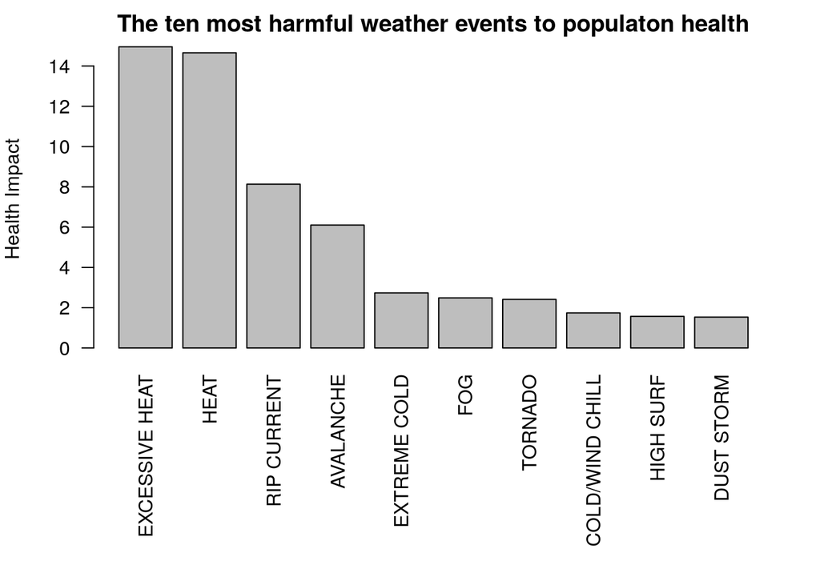

```r
evtohealth <- aggregate(data$HEALTH_IMPACT, by=list(data$EVTYPE), mean)
evtohealth <- head(evtohealth[order(evtohealth$x, decreasing = T),], 10)
par(mar = c(10,4,2,2))
barplot(evtohealth$x, names.arg = evtohealth$Group.1,
        ylab="Health Impact", las=2,
        main="The ten most harmful weather events to populaton health")
```

As we can see in the bar plot above, excessive heat and heat kill or injure with a great margin most people on average.

### Which types of events have the greatest economic consequences?

Again we’ll look at the top ten events. Our measure will be as in the question above the mean damage accumulated by the event.

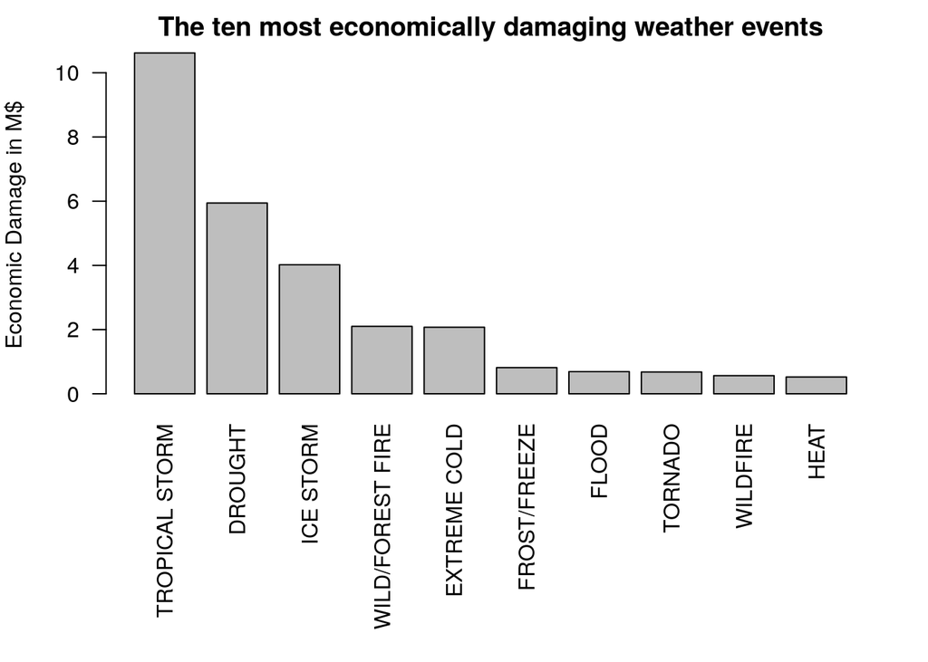

```r
evtohealth <- aggregate(data$CLEAN_DAMAGE, by=list(data$EVTYPE), mean)
evtohealth <- head(evtohealth[order(evtohealth$x, decreasing = T),], 10)
par(mar = c(10,4,2,2))
barplot(evtohealth$x / 10^6, names.arg = evtohealth$Group.1,
        ylab="Economic Damage in M$", las=2,
        main="The ten most economically damaging weather events")
```